# PAC4 - Anàlisi de la variància i repàs del curs

Jordi Marsal Poy

29/12/2019

# 1. - Introducció.

### Lectura

Es carreguen les dades

```r
oldwd = getwd() # d:/programfiles/rstudio
setwd("E:/UOC/UOC-MA01/5_ESTADISTICA/PAC4_ST")
dat <- read.csv("data/Wage.csv")
```

#### a)

Comproveu el tipus de variable que correspon a cada una de les variables.

```r
table(dat$maritl)
```

```
##
## 1. Never Married       2. Married       3. Widowed      4. Divorced
##              648             2074               19              204
##     5. Separated
##               55
```

```r
table(dat$race)
```

```
##
## 1. White 2. Black 3. Asian 4. Other
##     2480      293      190       37
```

```r
table(dat$education)
```

```
##
##       1. < HS Grad         2. HS Grad    3. Some College
##                268                971                650
##    4. College Grad 5. Advanced Degree
##                685                426
```

```r
table(dat$region)
```

```
##
## 2. Middle Atlantic
##               3000
```

```r
table(dat$jobclass)
```

```
##
##  1. Industrial 2. Information
##           1544           1456
```

```r
table(dat$health)
```

```
##
##      1. <=Good 2. >=Very Good
##            858           2142
```

```r
table(dat$health_ins)
```

```
##
## 1. Yes  2. No
##   2083    917
```

```r
#  NO hi ha nulls:
sapply(dat, function(x) (sum(is.na(x))))
```

```
##       year        age     maritl       race  education     region
##          0          0          0          0          0          0
##   jobclass     health health_ins    logwage       wage
##          0          0          0          0          0
```

No hi ha nulls.

#### b)

Quines són tipus numèric? Quines són tipus factor?

**Numériques:** year, age, logwage, wage.

**Factors:** maritl, race, education, region, jobclass, health, heath_ins.

# 2. - Estadística descriptiva i visualització.

#### a)

Realitzeu una descriptiva numèrica de les dades.

```r
dim(dat)
```

```
## [1] 3000   11
```

```r
head(dat)
```

```
##   year age           maritl     race       education             region
## 1 2006  18 1. Never Married 1. White    1. < HS Grad 2. Middle Atlantic
## 2 2004  24 1. Never Married 1. White 4. College Grad 2. Middle Atlantic
## 3 2003  45       2. Married 1. White 3. Some College 2. Middle Atlantic
## 4 2003  43       2. Married 3. Asian 4. College Grad 2. Middle Atlantic
## 5 2005  50      4. Divorced 1. White      2. HS Grad 2. Middle Atlantic
## 6 2008  54       2. Married 1. White 4. College Grad 2. Middle Atlantic
##         jobclass         health health_ins  logwage      wage
## 1  1. Industrial      1. <=Good      2. No 4.318063  75.04315
## 2 2. Information 2. >=Very Good      2. No 4.255273  70.47602
## 3  1. Industrial      1. <=Good     1. Yes 4.875061 130.98218
## 4 2. Information 2. >=Very Good     1. Yes 5.041393 154.68529
## 5 2. Information      1. <=Good     1. Yes 4.318063  75.04315
## 6 2. Information 2. >=Very Good     1. Yes 4.845098 127.11574
```

```r
str(dat)
```

```
## 'data.frame':    3000 obs. of  11 variables:
##  $ year      : int  2006 2004 2003 2003 2005 2008 2009 2008 2006 2004 ...
##  $ age       : int  18 24 45 43 50 54 44 30 41 52 ...
##  $ maritl    : Factor w/ 5 levels "1. Never Married",..: 1 1 2 2 4 2 2 1 1 2 ...
##  $ race      : Factor w/ 4 levels "1. White","2. Black",..: 1 1 1 3 1 1 4 3 2 1 ...
##  $ education : Factor w/ 5 levels "1. < HS Grad",..: 1 4 3 4 2 4 3 3 3 2 ...
##  $ region    : Factor w/ 1 level "2. Middle Atlantic": 1 1 1 1 1 1 1 1 1 1 ...
##  $ jobclass  : Factor w/ 2 levels "1. Industrial",..: 1 2 1 2 2 2 1 2 2 2 ...
##  $ health    : Factor w/ 2 levels "1. <=Good","2. >=Very Good": 1 2 1 2 1 2 2 1 2 2 ...
##  $ health_ins: Factor w/ 2 levels "1. Yes","2. No": 2 2 1 1 1 1 1 1 1 1 ...
##  $ logwage   : num  4.32 4.26 4.88 5.04 4.32 ...
##  $ wage      : num  75 70.5 131 154.7 75 ...
```

```r
summary(dat)
```

```
##       year           age                     maritl           race
##  Min.   :2003   Min.   :18.00   1. Never Married: 648   1. White:2480
##  1st Qu.:2004   1st Qu.:33.75   2. Married      :2074   2. Black: 293
##  Median :2006   Median :42.00   3. Widowed      :  19   3. Asian: 190
##  Mean   :2006   Mean   :42.41   4. Divorced     : 204   4. Other:  37
##  3rd Qu.:2008   3rd Qu.:51.00   5. Separated    :  55
##  Max.   :2009   Max.   :80.00
##               education                  region               jobclass
##  1. < HS Grad      :268   2. Middle Atlantic:3000   1. Industrial :1544
##  2. HS Grad        :971                             2. Information:1456
##  3. Some College   :650
##  4. College Grad   :685
##  5. Advanced Degree:426
##
##             health      health_ins      logwage           wage
##  1. <=Good     : 858   1. Yes:2083   Min.   :3.000   Min.   : 20.09
##  2. >=Very Good:2142   2. No : 917   1st Qu.:4.447   1st Qu.: 85.38
##                                      Median :4.653   Median :104.92
##                                      Mean   :4.654   Mean   :111.70
##                                      3rd Qu.:4.857   3rd Qu.:128.68
##                                      Max.   :5.763   Max.   :318.34
```

#### b)

Mostreu amb diversos diagrames de caixa la distribució de la variable wage segons:  
`race, jobclass, health i health_ins`. Interpretar els gràfics breument..

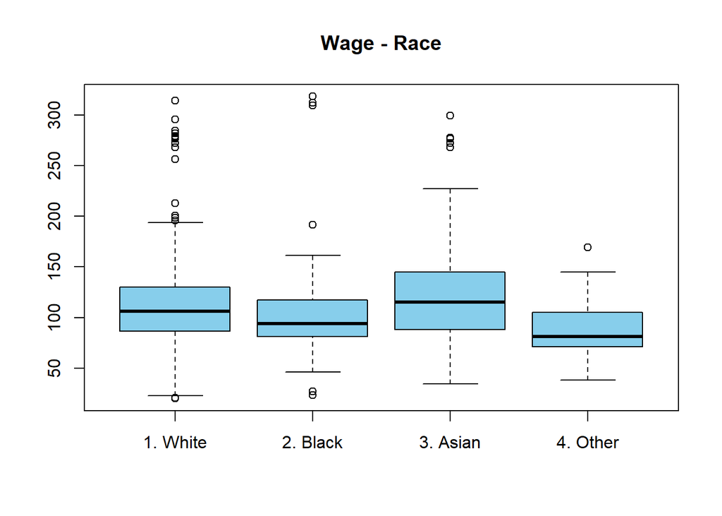

```r
bx2plot <- function(var, by, title){
  boxplot(var ~ by, main = title,xlab="", ylab = "",col = "skyblue")
}

#par(mfrow = c(4,1))

bx2plot(dat$wage, dat$race, "Wage - Race")
```

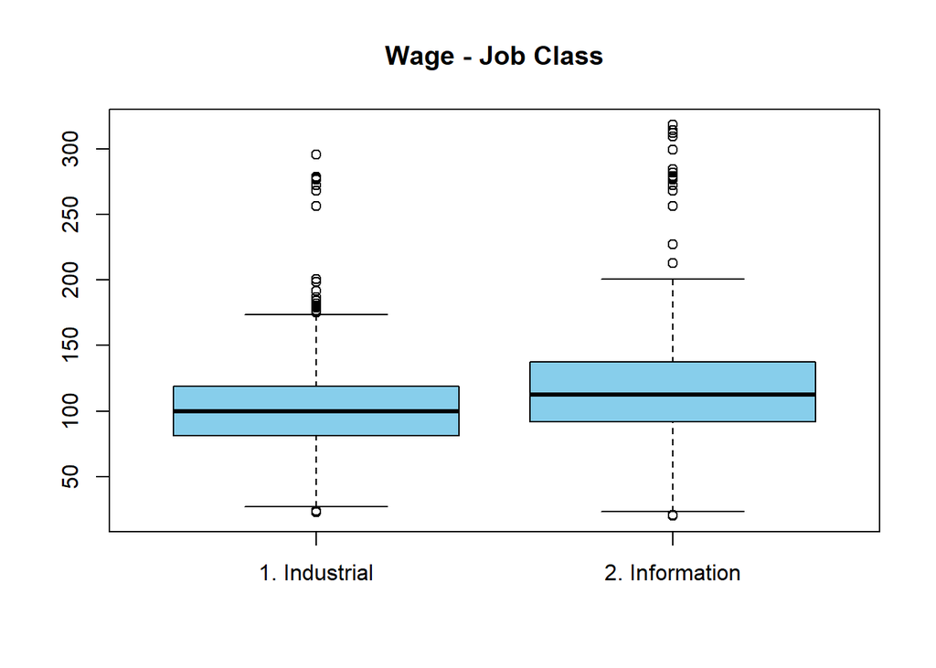

```r
bx2plot(dat$wage, dat$jobclass, "Wage - Job Class")
```

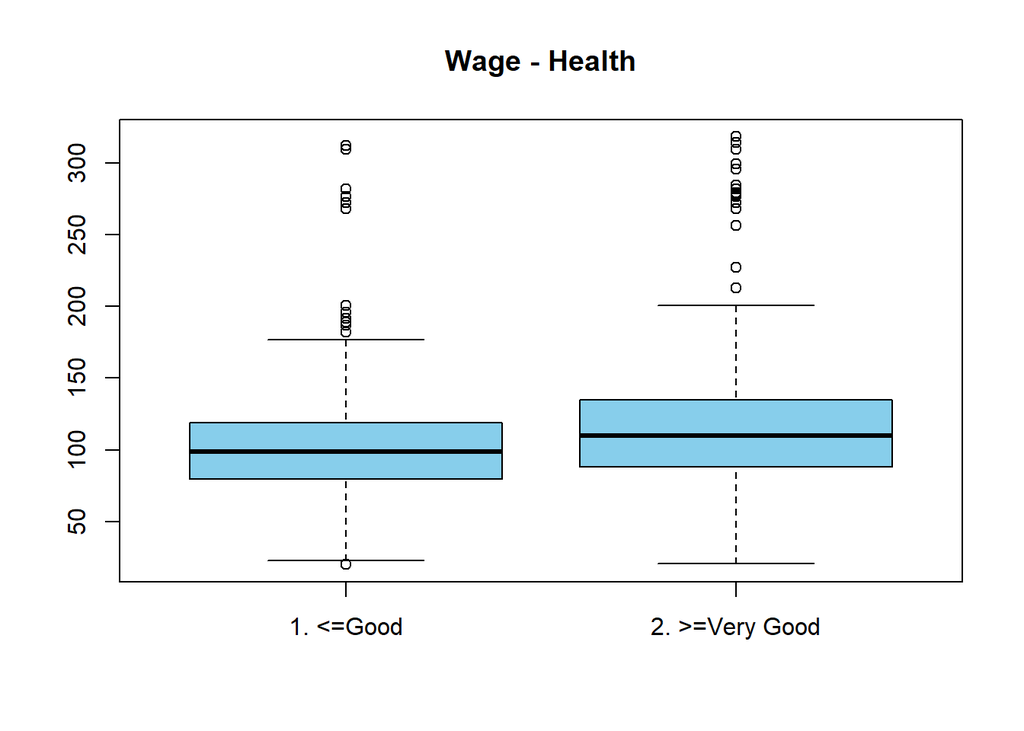

```r
bx2plot(dat$wage, dat$health, "Wage - Health")
```

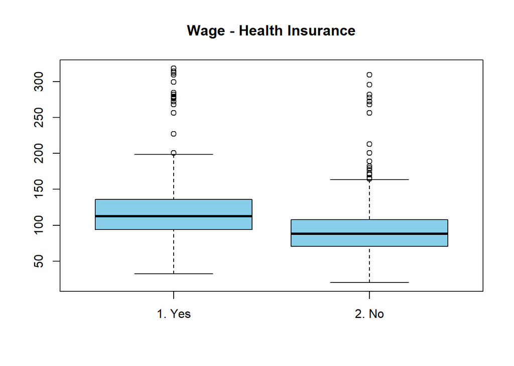

```r
bx2plot(dat$wage, dat$health_ins, "Wage - Health Insurance")
```

#### c)

Podem acceptar que la variable `wage` té distribució normal. Justifiqueu la vostra resposta recolzant-vos amb mètodes visuals.

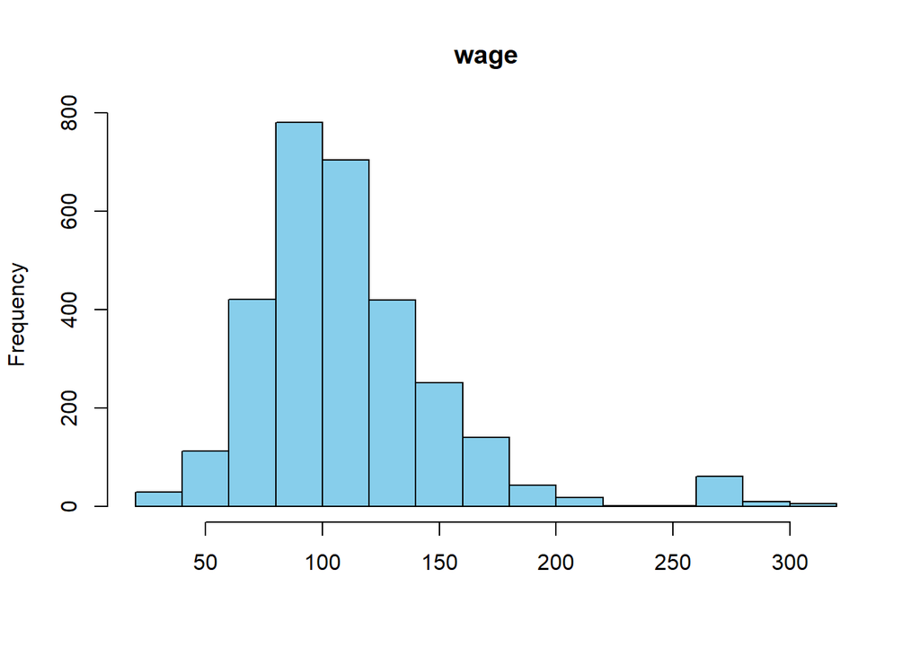

```r
hist(dat$wage, main = "wage",xlab = "", col = "skyblue")
```

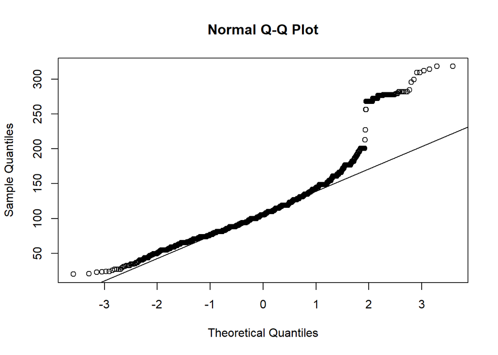

```r
qqnorm(dat$wage)
qqline(dat$wage)
```

```r
library(moments)

agostino.test(dat$wage)
```

```
##
##  D'Agostino skewness test
##
## data:  dat$wage
## skew = 1.6815, z = 26.9420, p-value < 2.2e-16
## alternative hypothesis: data have a skewness
```

```r
pTH <- function(res, alpha, title){
  writeLines(paste("H0:",title))
  if (res < alpha) writeLines(paste("Rebutjat H0. p-valor =",signif(res, digits = 3),"<",alpha))
  if (res >= alpha) writeLines(paste("No es rebutja H0. p-valor =",signif(res, digits = 3),">=",alpha))
}

osh = shapiro.test(dat$wage)

pTH(osh$p.value,0.05,paste("Distribució Normal. ",osh$method))
```

```
## H0: Distribució Normal.  Shapiro-Wilk normality test
## Rebutjat H0. p-valor = 2.46e-43 < 0.05
```

# 3. - Estadística inferencial

## 3.1 - Interval de confiança de la variable age

#### a)

Calcular l’interval de confiança al 95% de la variable **age** dels treballadors. A partir del valor obtingut, expliqui com s’interpreta el resultat de l’interval de confiança.

```r
alpha2 = (1-0.95)/2

writeLines(paste("alpha2 =",alpha2))
```

```
## alpha2 = 0.025
```

```r
getSigma <- function(var){
  sigmap = sqrt(mean(var^2) - mean(var)^2)
  return(sigmap)
}
getInterval <- function(var){
  alpha2 = 0.025
  z.star = abs(qnorm(alpha2))
  writeLines(paste("z.star =",z.star))
  xm = mean(var)
  n<-length(var)
  sigmap = getSigma(var)
  imin = round(xm - (sigmap/n) * z.star,4)
  imax = round(xm + (sigmap/n) * z.star,4)
  return(paste("(",imin,",",imax,")", collapse = ""))
}

writeLines(paste("Interval de confiança del 95% per Age =",getInterval(dat$age)))
```

```
## z.star = 1.95996398454005
## Interval de confiança del 95% per Age = ( 42.4071 , 42.4222 )
```

Els intervals de confiança ens permeten apropar, un cop calculat el valor de la variable en la mostra, entre quin rang de valors es troba el valor real inaccessible de la variable en la població, amb un grau d’incertesa que podem determinar. De forma estàndard es suposa en 95% de probabilitat.

#### b)

Calcular els intervals de confiança al 95% de la variable **age**, segregant els treballadors per la variable **jobclass**. Quina conclusió en treus de la comparació dels dos intervals, del fet que no es solapin?

Encara que la distribució d’**age** no és *Normal*, donat el teorema del límit central, s’assumeix que si la mida de les mostres es n > 30 es comportarà com una distribució normal estàndard (n=3000).

```r
with(beaver2, tapply(dat$age, dat$jobclass, getInterval))
```

```
## z.star = 1.95996398454005
## z.star = 1.95996398454005
```

```
##           1. Industrial          2. Information
## "( 41.3835 , 41.4132 )" "( 43.4773 , 43.5076 )"
```

Si els intervals no es solapen voldrà dir que el valor mínim de *Information* estarà sempre per sobre del valor màxim d’*Industrial* (amb una propabilitat del 95%). Per tant es conclou que tenen mesures diferents per cada **jobclass**.

http://archivos.pap.es/FrontOffice/PAP/front/Articulos/Articulo/_IXus5l_LjPrFG1u0ScQLB219Iu_k8s5e

## 3.2 - Test de comparació de dues mitjanes

Podem acceptar que els treballadors amb una polissa d’assegurança mèdica variable (`health_ins`) tenen en mitjana un salari (variable `wage`) que supera amb més de 20$ el salari dels que no tenen polissa?  
Calcular-per a un nivell de confiança del 95%.  
S’assumirà que la variable wage té distribució normal.

### 3.2.1 - Escriure la hipòtesi nul·la i alternativa.

#### H<sub>0</sub>: μ ≥ x + 20

#### H<sub>1</sub>: μ < x + 20

#### α = 0.05

### 3.2.2 - Justificar quin mètode aplicareu.

El mètode sel·lecionat és amb la mitja de la població i variància coneguda, seleccionant la cua més petita. En aquest cas, la cua esquerra.

### 3.2.3 - Realitzar els càlculs de l’estadístic de contrast, valor crític i p valor amb un nivell de confiança del 95%.

```r
w_ins = dat[c("wage")][(dat$health_ins == "1. Yes"),]
w_noins = dat$wage[dat$health_ins == "2. No"]

### # test estadístic
getZ <- function(var, mu0){
  xm = mean(var)
  n<-length(var)
  sigmap = getSigma(var)
  z = (xm - mu0)/(sigmap/sqrt(n))
  return(z)
}

nomi = mean(w_noins)
writeLines(paste("",nomi))
```

```
##  92.3167034506711
```

```r
z_ins = getZ(w_noins, nomi)

z_noins = getZ(w_noins, nomi+20)

writeLines(paste("Valor de z_noins =",round(z_noins,5)))
```

```
## Valor de z_noins = -16.84567
```

```r
writeLines(paste("Valor de z_ins =",round(z_ins,5)))
```

```
## Valor de z_ins = 0
```

Amb *z* ja es pot calcular el **valor crític** i el *p-value*:

```r
alpha= .05
alpha_mitjos = alpha / 2
# Valor crític
z.alpha =qnorm(1-alpha_mitjos)
writeLines(paste("Valor crític =",round(z.alpha,5)))
```

```
## Valor crític = 1.95996
```

```r
#pvalue
pvalue= pnorm(z_ins)
writeLines(paste("p-value =",signif(pvalue, digits = 3)))
```

```
## p-value = 0.5
```

El **p-valor** és **0.5**, molt més elevat que 0.05. Així doncs no es pot rebutjar la Hipòtesi H<sub>0</sub>, per tant no es pot rebutjar que els assalariats amb assegurança contractada guanyen 20$ ó més que els que no la tenen.

## 3.3 - Contrast no paramètric.

En l’apartat 2 hem descartat la normalitat de la variable salari (wage), apliqueu un test no parametric per respondre la pregunta anterior. Podeu usar una funció R per resoldre el contrast.

```r
agostino.test(dat$wage)
```

```
##
##  D'Agostino skewness test
##
## data:  dat$wage
## skew = 1.6815, z = 26.9420, p-value < 2.2e-16
## alternative hypothesis: data have a skewness
```

```r
osh = shapiro.test(dat$wage)

pTH(osh$p.value,0.05,paste("Distribució Normal. ",osh$method))
```

```
## H0: Distribució Normal.  Shapiro-Wilk normality test
## Rebutjat H0. p-valor = 2.46e-43 < 0.05
```

S’observa que el test **d’Agostino** de *skewness* rebutja que no hi hagi desviació (*skewness*) i finalment el test **Shapiro-Wilk** rebutja la Hipòtesi nul·la de la *Normalitat*.

# 4 - Regressió logística

## 4.1 - Model predictiu

#### a)

Ajusteu un model predictiu basat en la regressio logística per predir la probabilitat de tenir un salari superior a la mitjana en funció de les variables: `health_ins`, `jobclass` i `age`. Preneu com salari mitjà el valor de la mitjana mostral de la variable `wage`. Codificant 0 quan el salari és inferior i 1 quan el salari és superior o igual.

```r
wage_di = dat$wage
mw = mean(wage_di)
wage_di[wage_di < mw] <- 0
wage_di[wage_di >= mw] <- 1

results = glm(wage_di ~ health_ins + jobclass + age, data = dat,family = "binomial"(link='logit'))
summary(results)
```

```
##
## Call:
## glm(formula = wage_di ~ health_ins + jobclass + age, family = binomial(link = "logit"),
##     data = dat)
##
## Deviance Residuals:
##    Min      1Q  Median      3Q     Max
## -1.752  -1.042  -0.586   1.104   2.062
##
## Coefficients:
##                         Estimate Std. Error z value Pr(>|z|)
## (Intercept)            -1.373068   0.163067  -8.420  < 2e-16 ***
## health_ins2. No        -1.224173   0.093342 -13.115  < 2e-16 ***
## jobclass2. Information  0.586006   0.078709   7.445 9.68e-14 ***
## age                     0.025984   0.003509   7.405 1.31e-13 ***
## ---
## Signif. codes:  0 '***' 0.001 '**' 0.01 '*' 0.05 '.' 0.1 ' ' 1
##
## (Dispersion parameter for binomial family taken to be 1)
##
##     Null deviance: 4091.7  on 2999  degrees of freedom
## Residual deviance: 3726.2  on 2996  degrees of freedom
## AIC: 3734.2
##
## Number of Fisher Scoring iterations: 4
```

```r
# Exemple de predicció:
log.odds <- predict(results, data.frame(health_ins = "1. Yes",
                                        jobclass = "2. Information",
                                        age = 55))

p = round(exp(log.odds)/(1+exp(log.odds)),3)
writeLines(paste("Probabilitat de sou superior a la mitja =",p))
```

```
## Probabilitat de sou superior a la mitja = 0.655
```

https://rpubs.com/emilopezcano/logit

#### b)

Interpreteu el model ajustat. Expliqueu quina interpretació en feu de la contribució en el model de les variables regressores.

```r
exp(coefficients(results))
```

```
##            (Intercept)        health_ins2. No jobclass2. Information
##              0.2533284              0.2940007              1.7967984
##                    age
##              1.0263243
```

Totes tres variables **health_ins**, **jobclass** i **age** tenen una significació molt alta. El seu p-valor és molt petit. Concretament dos valors dels nivells de les variables *factors*.  
A més, l’**odds ratio** mostra en quina mesura cada variable intervé:

En el cas de **jobclass** [Information], un punt significa una probabilitat del 80% (només hi ha dos valors)

**age** finalment intervé en un 2.6% donant que per cada 10 anys la probabilitat serà d’un 26% d’increment.

## 4.2 - Importancia del nivell d’estudis.

#### c)

Afegiu en el model anterior la variable `education`. Interpretar els nivells de la variable `education` a partir dels odds ratio. En quin % es veu incrementada la probabilitat de tenir un salari superior al salari mitjà segons el nivell educatiu? Proporcioneu intervals de confiança del 95% dels odds ratio.

```r
rl_edu = glm(wage_di ~ health_ins + jobclass + age + education, data = dat,family = "binomial"(link='logit'))
summary(rl_edu)
```

```
##
## Call:
## glm(formula = wage_di ~ health_ins + jobclass + age + education,
##     family = binomial(link = "logit"), data = dat)
##
## Deviance Residuals:
##     Min       1Q   Median       3Q      Max
## -2.2149  -0.8726  -0.4314   0.8940   2.5503
##
## Coefficients:
##                              Estimate Std. Error z value Pr(>|z|)
## (Intercept)                 -2.788611   0.264697 -10.535  < 2e-16 ***
## health_ins2. No             -1.108971   0.102322 -10.838  < 2e-16 ***
## jobclass2. Information       0.105917   0.088599   1.195  0.23191
## age                          0.028543   0.003862   7.390 1.47e-13 ***
## education2. HS Grad          0.647155   0.206820   3.129  0.00175 **
## education3. Some College     1.363390   0.210033   6.491 8.51e-11 ***
## education4. College Grad     2.214955   0.209626  10.566  < 2e-16 ***
## education5. Advanced Degree  3.190188   0.233075  13.687  < 2e-16 ***
## ---
## Signif. codes:  0 '***' 0.001 '**' 0.01 '*' 0.05 '.' 0.1 ' ' 1
##
## (Dispersion parameter for binomial family taken to be 1)
##
##     Null deviance: 4091.7  on 2999  degrees of freedom
## Residual deviance: 3242.6  on 2992  degrees of freedom
## AIC: 3258.6
##
## Number of Fisher Scoring iterations: 4
```

```r
exp(cbind("Odds ratio" = coef(rl_edu), confint.default(rl_edu, level = 0.95)))
```

```
##                              Odds ratio       2.5 %     97.5 %
## (Intercept)                  0.06150659  0.03661095  0.1033314
## health_ins2. No              0.32989831  0.26994993  0.4031596
## jobclass2. Information       1.11172958  0.93450869  1.3225588
## age                          1.02895467  1.02119461  1.0367737
## education2. HS Grad          1.91009903  1.27353400  2.8648456
## education3. Some College     3.90942444  2.59019679  5.9005553
## education4. College Grad     9.16100049  6.07447791 13.8158260
## education5. Advanced Degree 24.29299592 15.38462892 38.3596936
```

https://stats.stackexchange.com/q/304909

La probabilitat augmenta molt per cada esglaó d’educació, sent 25 vegades en cas d’ ‘Advanced Degree’.

## 4.3 - Predicció.

#### d)

Superaria el salari mitjà un treballador que té polissa mèdica, que treballa a l’àmbit de la informació i té 42 anys d’edat amb formació de graduat? I si es tracta d’un treballador de l’àmbit industrial?

```r
# Exemple de predicció:
log.odds <- predict(rl_edu, data.frame(health_ins = "1. Yes",
                                       jobclass = "2. Information",
                                       age = 42,
                                       education = "5. Advanced Degree"))

p = round(exp(log.odds)/(1+exp(log.odds)),3)
writeLines(paste("Informació: Probabilitat de sou superior a la mitja =",p))
```

```
## Informació: Probabilitat de sou superior a la mitja = 0.846
```

```r
log.odds <- predict(rl_edu, data.frame(health_ins = "1. Yes",
                                       jobclass = "1. Industrial",
                                       age = 42,
                                       education = "4. College Grad"))

p = round(exp(log.odds)/(1+exp(log.odds)),3)
writeLines(paste("Industrial: Probabilitat de sou superior a la mitja =",p))
```

```
## Industrial: Probabilitat de sou superior a la mitja = 0.651
```

# 5 Anàlisi de la variància (ANOVA)

## 5.1 - Anova d’un factor

### 5.1.1 - Nivell d’educació i salari

Seleccionar les observacions que tinguin un salari inferior a 150. Per aquest grup de traballadors realitzeu un Anova per contrastar la significació del factor nivell d’eduació en el salari.

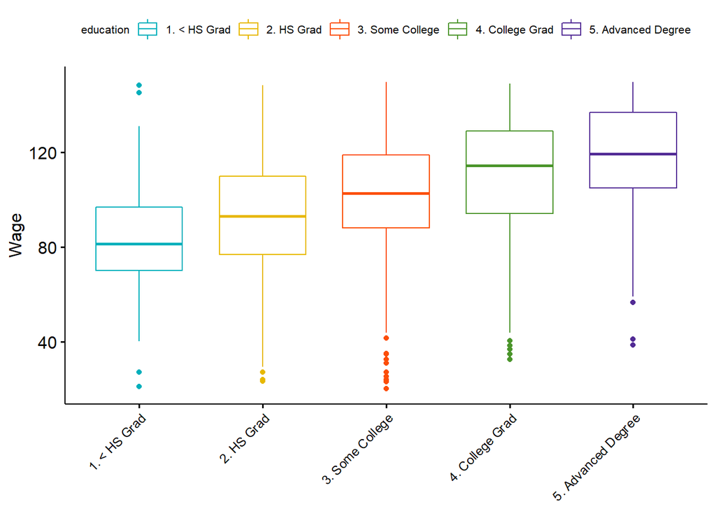

```r
below = dat[dat$wage < 150,]

library("ggpubr")
ggboxplot(below, x = "education", y = "wage",
          color = "education", palette = c("#00AFBB", "#E7B800", "#FC4E07","#4B952B", "#522B95"),
          order = c("1. < HS Grad", "2. HS Grad", "3. Some College", "4. College Grad", "5. Advanced Degree"),
          x.text.angle = 45,
          font.xtickslab = c(9, "plain", "black"),
          font.legend = c(8, "plain", "black"),
          ylab = "Wage", xlab = FALSE)
```

https://rpkgs.datanovia.com/ggpubr/reference/ggpar.html

### 5.1.1.1 - Hipòtesis nul·la i alternativa

#### H<sub>0</sub>: μ<sub>1</sub> = μ<sub>2</sub>= … = μ<sub>n</sub>

#### H<sub>1</sub>: μ<sub>1</sub> ≠ … μ<sub>n</sub>

#### α = 0.05

### 5.1.1.2 - Model

Calcular l’anàlisi de variància, utilitzant la funció aov o lm. Interpretar el resultat de l’anàlisi, tenint en compte els valors Sum Sq, Mean SQ, F i Pr (> F).

```r
res.aov <- aov(wage ~ education, data = below)
summary(res.aov)
```

```
##               Df  Sum Sq Mean Sq F value Pr(>F)
## education      4  267049   66762   120.5 <2e-16 ***
## Residuals   2652 1468949     554
## ---
## Signif. codes:  0 '***' 0.001 '**' 0.01 '*' 0.05 '.' 0.1 ' ' 1
```

http://www.sthda.com/english/wiki/one-way-anova-test-in-r

La suma dels quadrats (**SS** o **Sum Sq**) és de tipus 1 (* tenen en compte la mida de les series, no depenen del ordre, dwoll.de/r/ssTypes.php ).

La **Mean Sq** es calcula amb aquesta SS (MCE = SCE/(k-1); MCD = SCD/(n-k)).

El *F valor* és **l’estadístic de contrast** SCE/(k-1) / SCD/(n-k) i senyala la zona d’acceptació o no del valor com pertanyent a la distribució F de Snedecor.

El **Pr (> F)** és el p-valor i ens mostra la probabilitat.

En aquest cas el p-valor es molt proper a cero, rebutjant-se la H<sub>0</sub>, per tant **les mitjanes no són iguals**.

### 5.1.1.3 - Càlculs

#### a)

Per tal d’aprofundir en la comprensió de el model ANOVA, calcular manualment la suma de quadrats intra i la suma de quadrats entre grups. Els resultats han de coincidir amb el resultat de el model ANOVA. Com a referència, pots obtenir les fórmules de López-Roldán i Fachelli (2015), pàgines 29-33.

```r
SCT <- function(df, factor_){
  wages <- split(df$wage, factor_)
  m <- c(); l <- c();  v <- c()
  for (i in wages){
    l <- c(l,length(i))
    m <- c(m,mean(i))
    v <- c(v,var(i))
  }
  d_ = 0;  n_ = 0
  for (i in 1:length(l)){
    n_ = n_ + m[i] * l[i]
    d_ = d_ + l[i]
  }
  mean_global = n_ / d_
  scd = 0
  for (i in 1:length(l)){
    scd = scd + ((l[i]-1) * v[i])
  }
  writeLines(paste("SCD =",round(scd,0)))
  sce = 0
  for (i in 1:length(l)){
    sce = sce + (l[i] * (m[i]-mean_global)^2)
  }
  writeLines(paste("SCE =",round(sce,0)))
}

SCT(below,below$education)
```

```
## SCD = 1468949
## SCE = 267049
```

#### b)

També proporciona l’estimació dels efectes del nivells dels factor educació. I l’estimació de la variancia de l’error.  
Comprovació amb la funció lm().

```r
summary.lm(res.aov)
```

```
##
## Call:
## aov(formula = wage ~ education, data = below)
##
## Residuals:
##     Min      1Q  Median      3Q     Max
## -82.784 -14.890   0.092  16.176  64.564
##
## Coefficients:
##                             Estimate Std. Error t value Pr(>|t|)
## (Intercept)                   83.849      1.440  58.215  < 2e-16 ***
## education2. HS Grad            9.809      1.630   6.018 2.01e-09 ***
## education3. Some College      19.020      1.726  11.021  < 2e-16 ***
## education4. College Grad      26.730      1.749  15.280  < 2e-16 ***
## education5. Advanced Degree   34.943      2.043  17.106  < 2e-16 ***
## ---
## Signif. codes:  0 '***' 0.001 '**' 0.01 '*' 0.05 '.' 0.1 ' ' 1
##
## Residual standard error: 23.54 on 2652 degrees of freedom
## Multiple R-squared:  0.1538, Adjusted R-squared:  0.1526
## F-statistic: 120.5 on 4 and 2652 DF,  p-value: < 2.2e-16
```

### 5.1.2 - Interpretació dels resultats:

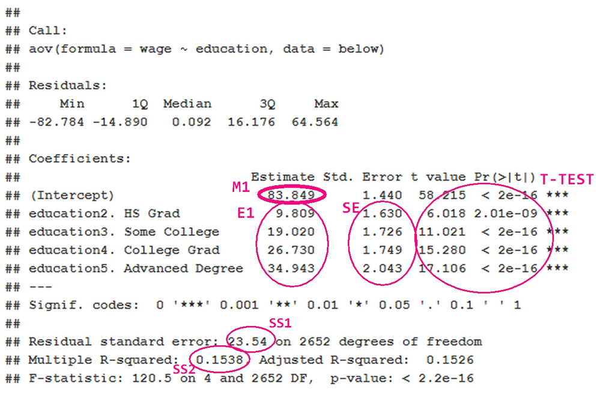

- **M1** -> Mitja base.
- **E1** -> Estimacions per la diferència entre les mitges de cada grup i el grup de control.
- **SE** -> Error estàndar de les diferències de mitges usant el *MSE* i **n** per grup.
- **T-TEST** -> T-test per no diferències entre mitges.
- **SS1** -> Arrel quadrada de la mitja de quadrats residuals (*SCD*).
- **SS2** -> SSTreatment / SSTotal.

http://homepages.inf.ed.ac.uk/bwebb/statistics/ANOVA_in_R.pdf

## 5.2 - Adequació del model

Mostra visualment l’adequació de el model ANOVA. Podeu fer servir plot sobre el model ANOVA resultant. En els apartats següents es demana la interpretació d’aquests gràfics.

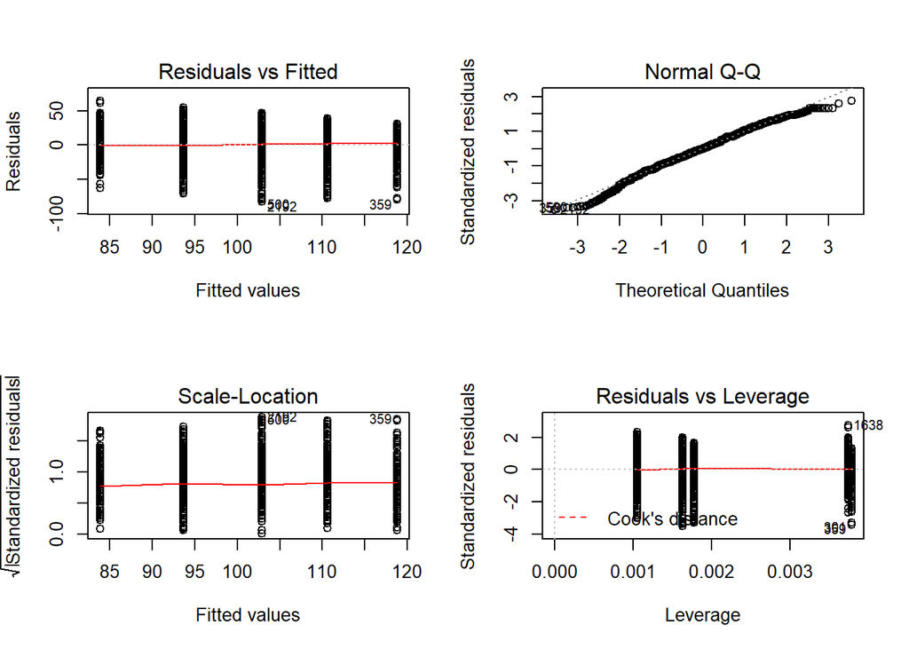

```r
par(mfrow = c(2,2))
plot(res.aov)
```

### 5.2.1 - Normalitat dels residus:

Interpretar la normalitat dels residus a partir de l’gràfic Normal Q-Q que es mostra en l’apartat anterior.

```r
aov_residuals <- residuals(object = res.aov )
shapiro.test(x = aov_residuals )
```

```
##
##  Shapiro-Wilk normality test
##
## data:  aov_residuals
## W = 0.99314, p-value = 7.228e-10
```

http://www.sthda.com/english/wiki/one-way-anova-test-in-r

Per tal de comprobar la normalitat de la distribució, es mostren els resultats sobre la diagonal, quant més propers a la diagonal, més normal.

El test de *Shapiro-Wilk* dóna que el p-valor es menor que 0.05, rebutjant la H<sub>0</sub> = Distribució Normal. Encara que el gràfic no mostra clarament aquesta falta de normalitat en la distribució.

### 5.2.2 - Homocedasticitat dels residus:

Els gràfics “Residuals vs Fitted”, “Scale-Location” i “Residuals vs Factor levels” donen informació sobre la homocedasticitat dels residus. Interpretar aquests gràfics.

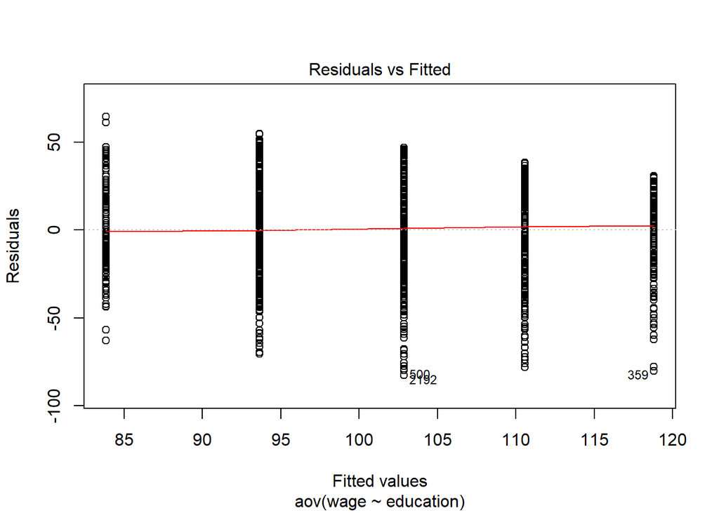

```r
plot(res.aov,1)
```

```r
library(car)
leveneTest(wage ~ education, data = below)
```

```
## Levene's Test for Homogeneity of Variance (center = median)
##         Df F value  Pr(>F)
## group    4  3.0748 0.01542 *
##       2652
## ---
## Signif. codes:  0 '***' 0.001 '**' 0.01 '*' 0.05 '.' 0.1 ' ' 1
```

Segons aquest gràfic, hi ha alguns *outliers*: els punts 500, 2192 i 359 es marquen clarament.  
Els altres gràfics no mostren desviacions significatives.

## 5.3 - ANOVA no paramètric

Si la validació de les premisses de normalitat i homocedasticitat no es verifiquen es pot aplicar un test no paramètric, per exemple el test de Kruskal-Wallis.  
Apliqueu un test de Kruskal-Wallis per contrastar si hi ha diferencies entre les etnies (race) pel que fa al salari. Com en l’apartat anterior seleccioneu les observacions amb salari inferior a 150, a més a més, descarteu les que a la variable race tinguin ell valor “4. Other”.

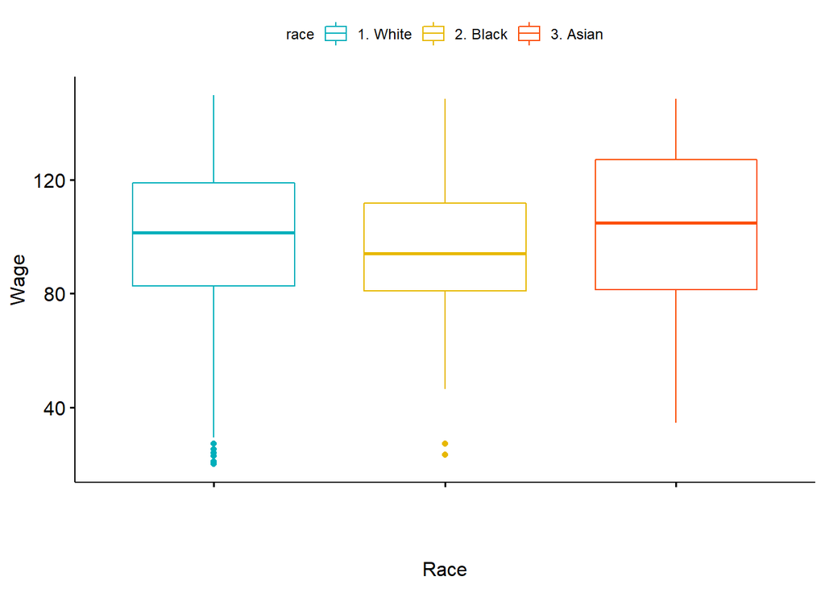

```r
below_no4 = below[below$race != "4. Other",]

ggboxplot(below_no4, x = "race", y = "wage",
          color = "race", palette = c("#00AFBB", "#E7B800", "#FC4E07"),
          order = c("1. White", "2. Black", "3. Asian", "4. Other"),
          x.text.angle = 45,
          font.xtickslab = FALSE,
          font.legend = c(9, "plain", "black"),
          ylab = "Wage", xlab = "Race")
```

```r
race.kruskal <- kruskal.test(wage ~ race, data = below_no4)
race.kruskal
```

```
##
##  Kruskal-Wallis rank sum test
##
## data:  wage by race
## Kruskal-Wallis chi-squared = 11.661, df = 2, p-value = 0.002937
```

### 5.3.1 - Interpretació dels resultats:

Com el **p-valor** és menor que **0.05** es pot determinar que hi ha diferències significatives entre els grups donats.

# 6 - ANOVA multifactorial

A continuació, es vol avaluar l’efecte de l’ètnia combinat com un altre factor. Primer es realitzarà el anàlisi amb el factor tipus de treball (`jobclass`) i posteriorment, amb el factor nivell d’educació (`education`). En aquest apartat es tindrà en compte el subset format per les observacions amb salari inferior a 150 i, a més a més, descarteu les que a la variable `race` tinguin el valor “4. Other”, tal com s’ha fet en l’apartat anterior.

```r
adjusted = below[c("wage","race","jobclass","education")]
ben4 = adjusted[adjusted$race != "4. Other",]
```

## 6.1 - Factors: ètnia i tipus de treball

### 6.1.1 - Anàlisis visual dels efectes principals i possibles interaccions

Dibuixar en un gràfic la variable `wage` en funció de l’ètnia (`etnia`) i en funció del tipus de treball (`jobclass`) i, en el seu cas, en funció del nivell educatiu (`education`). El gràfic ha de permetre avaluar si hi ha interacció entre els dos factors. Per això, es recomana que segueixi els passos:

1. Agrupar el conjunt de dades per ètnia i per tipus de treball. Calcular la mitjana del salari per a cada grup. Per realitzar aquest procés, es pot fer amb les funcions `group_by` i `summarise` de la llibreria `dplyr`.

```r
library(dplyr)
byRJE <- ben4 %>%
    group_by(race,jobclass,education) %>%
    summarise_at(vars(wage), funs(mean(., na.rm=TRUE)))
library(data.table)
setattr(byRJE$race,"levels",c("1. White", "2. Black", "3. Asian"))
```

https://stackoverflow.com/a/28677167

2. Mostrar el conjunt de dades en forma de taula, on es mostri la mitjana de cada grup segons ètnia i el tipus de treball.

```r
library(expss)
byRJE %>%
  tab_cells(round(wage,1)) %>%
  tab_cols(race, jobclass) %>%
  tab_stat_cpct() %>%
  tab_pivot()
```

|  | race 1. White | race 2. Black | race 3. Asian |  | jobclass 1. Industrial | jobclass 2. Information |
| --- | --- | --- | --- | --- | --- | --- |
| round(wage, 1) |  |  |  |  |  |  |
| 75.1 |  |  | 10 |  | 6.7 |  |
| 75.2 |  |  | 10 |  |  | 6.7 |
| 81.5 |  |  | 10 |  | 6.7 |  |
| 83 | 10 |  |  |  | 6.7 |  |
| 84.9 |  | 10 |  |  | 6.7 |  |
| 87.5 | 10 |  |  |  |  | 6.7 |
| 88 |  | 20 |  |  | 6.7 | 6.7 |
| 88.3 |  |  | 10 |  |  | 6.7 |
| 90.5 |  | 10 |  |  |  | 6.7 |
| 94 | 10 |  |  |  | 6.7 |  |
| 94.4 |  |  | 10 |  |  | 6.7 |
| 95.2 |  | 10 |  |  | 6.7 |  |
| 96.6 | 10 |  |  |  |  | 6.7 |
| 97.9 |  | 10 |  |  |  | 6.7 |
| 99.9 |  | 10 |  |  | 6.7 |  |
| 100.8 |  |  | 10 |  | 6.7 |  |
| 102.2 | 10 |  |  |  | 6.7 |  |
| 105.2 |  | 10 |  |  |  | 6.7 |
| 105.7 | 10 |  |  |  |  | 6.7 |
| 107.4 |  |  | 10 |  | 6.7 |  |
| 109.6 | 10 |  |  |  | 6.7 |  |
| 110.9 | 10 |  |  |  | 6.7 |  |
| 111.4 | 10 |  |  |  |  | 6.7 |
| 114.5 |  | 10 |  |  | 6.7 |  |
| 116.9 |  |  | 10 |  |  | 6.7 |
| 119.3 |  |  | 10 |  |  | 6.7 |
| 121.7 | 10 |  |  |  |  | 6.7 |
| 122.3 |  |  | 10 |  | 6.7 |  |
| 122.7 |  | 10 |  |  |  | 6.7 |
| #Total cases | 10 | 10 | 10 |  | 15 | 15 |

3. Mostra en un gràfic el valor mitjà de la variable `wage` per a cada ètnia i tipus de treball. Pots inspirar-te en els gràfics de López-Roldán i Fachelli (2015), p.38. Pots realitzar aquest tipus de gràfic usant la funció `ggplot` de la llibreria `ggplot2`.

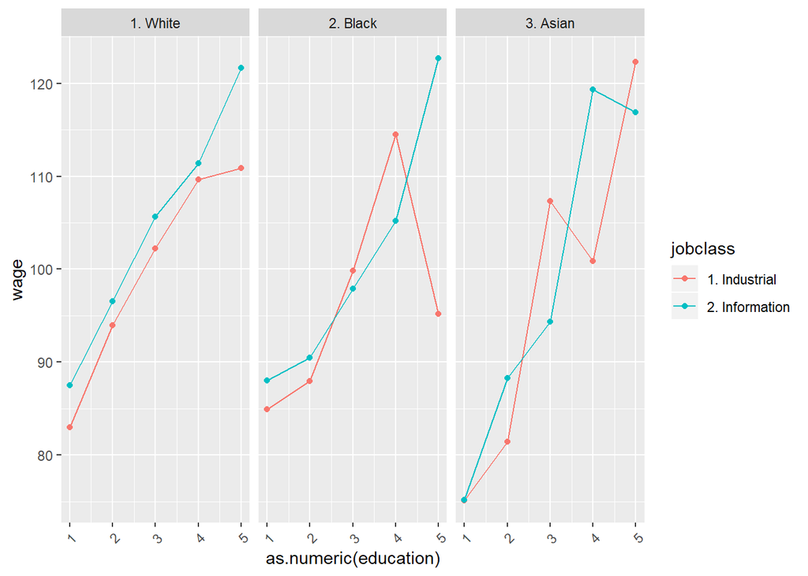

[figure not shown]

```r
library(ggplot2)
ggplot(byRJE, aes(x = as.numeric(education), y = wage, colour = jobclass)) +
  geom_line(aes(color=jobclass)) +
  geom_point() +
  facet_wrap( ~ race) +
  theme(axis.text.x=element_text(angle=45, hjust=1))
```

**as.numeric** elimina les etiquetes de l’educació, però sense no es generen les linies al ser un factor.

https://stackoverflow.com/a/15546667 & https://stackoverflow.com/a/31818454

4. Interpretar el resultat sobre si només hi ha efectes principals o hi ha interacció entre els factors. si hi ha interacció, explicar com s’observa aquesta interacció en el gràfic.

Caldrà analitzar si la possible interacció observada gràficament és significativa.

### 6.1.2 Adequació del model

Interpretar l’adequació de el model ANOVA obtingut usant els gràfics de residus.

```r
m1 = aov(wage ~ race * education,data=byRJE)
summary(m1)
```

```
##                Df Sum Sq Mean Sq F value   Pr(>F)
## race            2    100    50.2   0.937    0.414
## education       4   4464  1115.9  20.838 5.51e-06 ***
## race:education  8    308    38.5   0.720    0.672
## Residuals      15    803    53.6
## ---
## Signif. codes:  0 '***' 0.001 '**' 0.01 '*' 0.05 '.' 0.1 ' ' 1
```

```r
m2 = aov(wage ~ race * jobclass,data=byRJE)
summary(m2)
```

```
##               Df Sum Sq Mean Sq F value Pr(>F)
## race           2    100   50.19   0.220  0.804
## jobclass       1     90   89.84   0.394  0.536
## race:jobclass  2     16    8.05   0.035  0.965
## Residuals     24   5469  227.89
```

## 6.2 Factors: ètnia i nivell d’educació

### 6.2.1 Anàlisis visual dels efectes principals i possibles interaccions

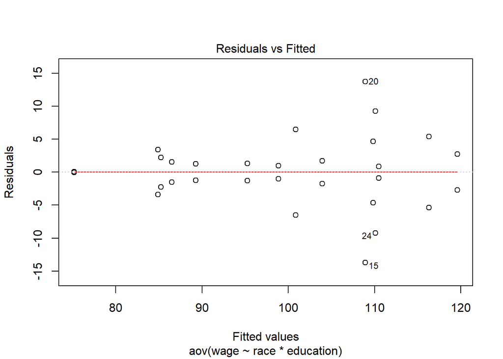

```r
plot(m1,1)
```

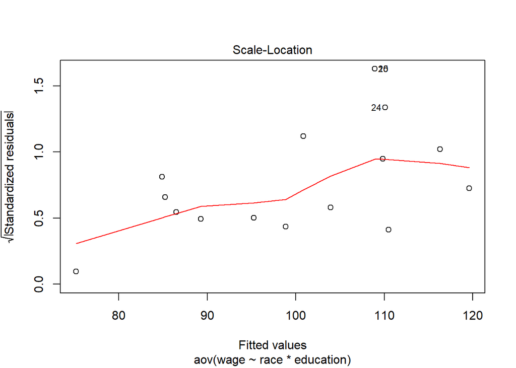

```r
plot(m1,3)
```

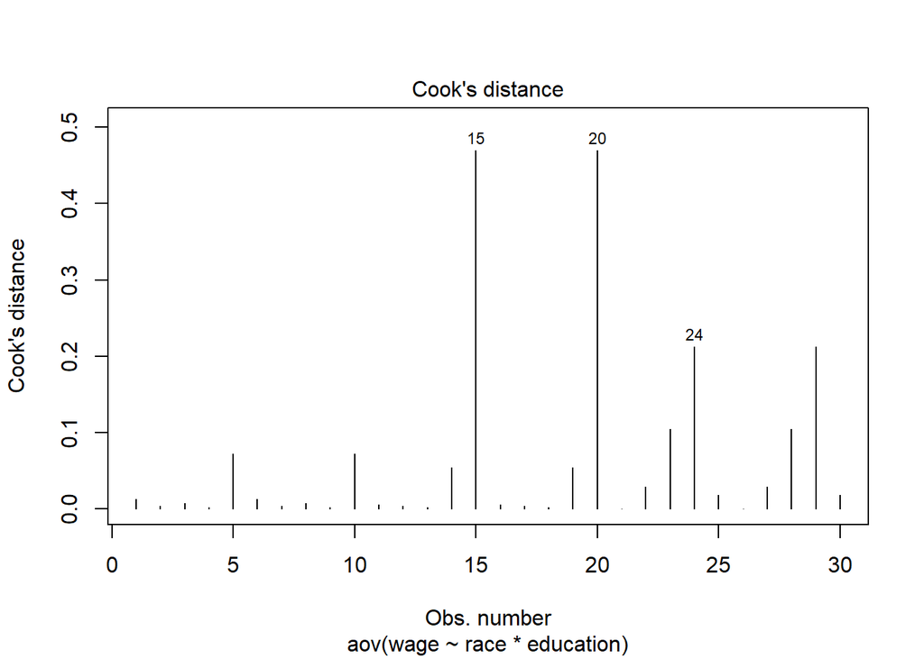

```r
plot(m1,4)
```

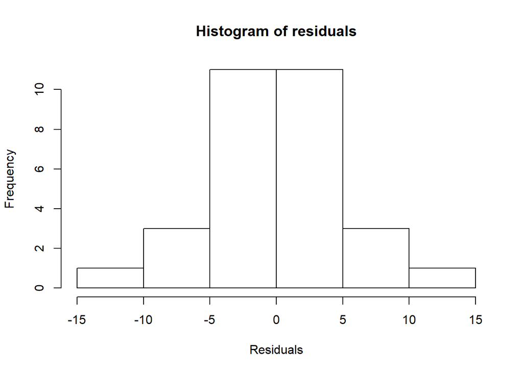

```r
res <- m1$residuals
hist(res,main="Histogram of residuals",xlab="Residuals")
```

Segons els resultats del model, l’educació sí que és significativa, però molt menys ho es la etnia o el tipus de treball que no tenen p-valors ni tan sols propers a 0.05.  
Gràficament:

- **Residuals vs Fitted** : mostra alguns outliers al punt 110.
- **Scale-Location**: s’observa que no hi ha un patró aleatori, podent significar que **la variable afecta la resposta**.
- **Cook’s distance**: mostra els punts amb major influència (*leverage points*). Que són els mateixos que ja s’ha detectat com outliers: 15, 20 i 24.
- **Histograma de residus**: és centrat i *normal* no apareix cap presència d’*outliers* ni *skewness*.

https://support.minitab.com/en-us/minitab-express/1/help-and-how-to/modeling-statistics/anova/how-to/two-way-anova/interpret-the-results/all-statistics-and-graphs/

https://www.theanalysisfactor.com/linear-models-r-diagnosing-regression-model/

# 7 Comparacions múltiples

Prenent com a referència el model ANOVA multifactorial, amb els factors ètnia i tipus de treball, aplicar el test de comparació múltiple Scheffé. Interpretar el resultat del test i indicar quins grups són diferents significativament entre si.

```r
m2 = aov(wage ~ race * jobclass,data=byRJE)
summary(m2)
```

```
##               Df Sum Sq Mean Sq F value Pr(>F)
## race           2    100   50.19   0.220  0.804
## jobclass       1     90   89.84   0.394  0.536
## race:jobclass  2     16    8.05   0.035  0.965
## Residuals     24   5469  227.89
```

```r
library(agricolae)
comparison <- scheffe.test(m2,"race", group=TRUE,console=TRUE,
main="Wages\nBy different race")
```

```
##
## Study: Wages
## By different race
##
## Scheffe Test for wage
##
## Mean Square Error  : 227.8931
##
## race,  means
##
##               wage      std  r      Min      Max
## 1. White 102.24479 11.97365 10 82.99862 121.6763
## 2. Black  98.67078 12.31095 10 84.94291 122.6569
## 3. Asian  98.11759 18.01551 10 75.11866 122.3126
##
## Alpha: 0.05 ; DF Error: 24
## Critical Value of F: 3.402826
##
## Minimum Significant Difference: 17.61227
##
## Means with the same letter are not significantly different.
##
##               wage groups
## 1. White 102.24479      a
## 2. Black  98.67078      a
## 3. Asian  98.11759      a
```

https://rdrr.io/cran/agricolae/man/scheffe.test.html

Segons el resultat del test de **Scheffe**, no hi ha diferències significatives entre les mitges de cada grup per `wage` ~ `race` * `jobclass`.

# 8 - Conclusions

S’ha portat a terme un repàs general de l’assignatura amb l’afegit del anàlisi de la variància.

S’ha estudiat el conjunt de dades segons l’**estadística descriptiva**. S’ha visaualitzat els gràfica més habituals, com els boxplots de les variables a estudiar, l’ histograma per `wage` i el **qqplot** per trobar la *normalitat* de `wage` ja que es la variable resultant que s’estudia.

Segons l’**estadística inferencial** s’ha estudiat l’interval de confiança per `age`, s’ha comparat la mitjana de `wage` segons si el treballador te o no `health_ins` on s’ha trobat que una mateixa variable pot ser estudiada paramètricament o no paramètricament només canviant com es fan les sub seleccions.

Amb la **regressió logística** s’ha vist com agrupar i com predir segons una certa quantitat de variables amb un resultat de probabilitat i com depenen les variables entre si per obtenir aquestes prediccions.

**ANOVA** mostra la comparació de variància entre varies variables o per una variable segons un o més factors. Inclós sense normalitat en les sèries gràcies al test de *Kruskall-Wallis*.

* Nota: els arxius annexes footer.html i style.css només s'han afegit perquè no doni error l'execució del .Rmd